# My R Markdown Primer

VaShay Carpenter

2026-04-13

Create an R Markdown File In RStudio, go to File → New File → R Markdown… and choose HTML output. Give it a title (e.g., “My R Markdown Primer”) and author metadata.

Populate the Document Write sections that include:

A brief introduction explaining what R Markdown is.

# R Markdown is a file format for making dynamic documents with R. An R Markdown document is written in markdown (an easy-to-write plain text format)

At least one narrative paragraph (Markdown text).

At least one LaTeX math expression (e.g., inline $\\alpha + \\beta = \\gamma$ and a displayed equation).

At least two executable R code chunks that: Load a library or dataset. Run a simple analysis or generate a plot (e.g., summary statistics or ggplot2 chart).

A concluding reflection on your experience using R Markdown vs. writing plain reports.

Compile and Review Knit the document to HTML (or PDF) and save the output. Compare the source .Rmd file side‑by‑side with the rendered output. Note any formatting surprises or tips you discovered.

Submission Instructions GitHub: Push your .Rmd source file and the rendered HTML (or PDF) to your GitHub repository. Blog Post: Write a short reflection on your blog about: What you learned about Markdown syntax and LaTeX math. How code chunks and narrative sections integrate. Any challenges you faced in authoring or knitting.

Include a link to your GitHub repository in the blog post.

Canvas: Submit the URLs for your GitHub repo and blog post under “Assignment #12.”

# First executable R code chunk:

```r
#Load a dataset and library
library(ggplot2)
data("mpg")
```

# Second executable R code chunk:

```r
#Simple analysis
summary(mpg$hwy)
```

```
##    Min. 1st Qu.  Median    Mean 3rd Qu.    Max.
##   12.00   18.00   24.00   23.44   27.00   44.00
```

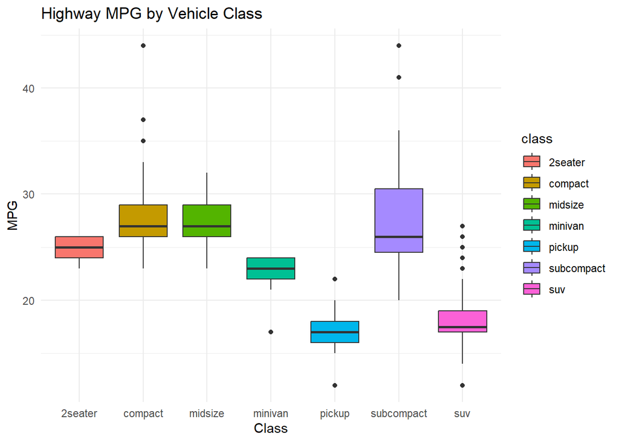

```r
#Generate a ggplot2 chart
ggplot(mpg, aes(x=class, y=hwy, fill=class)) +
  geom_boxplot() +
  theme_minimal() +
  labs(title="Highway MPG by Vehicle Class", x="Class", y="MPG")
```

# Concluding reflection on experience using R Markdown vs. writing plain reports.

Using R Markdown is significantly more efficient than writing plain reports. In a plain report, if the data changes, I have to manually update every table and plot. With R Markdown, I simply “Knit” the document again, and every visualization and statistic updates automatically. This ensures accuracy and reproducibility in my library science audits.